# Assignment 1.3

Matt Wanner

#### INSTRUCTIONS:

- Be sure you have **all** necessary files
- Type your answers on the space provided under each problem.
- You can embed an R code chunk like this:

  ```r
  summary(cars)
  ```

  ```
  ##      speed           dist
  ##  Min.   : 4.0   Min.   :  2.00
  ##  1st Qu.:12.0   1st Qu.: 26.00
  ##  Median :15.0   Median : 36.00
  ##  Mean   :15.4   Mean   : 42.98
  ##  3rd Qu.:19.0   3rd Qu.: 56.00
  ##  Max.   :25.0   Max.   :120.00
  ```

- After you are done click the **Knit HTML** button. A document will be generated that includes both content as well as the output of any embedded R code chunks within the document.
- Go to File –> Save. Name your file.
- Upload the file to the Canvas site by using the link provided.

##### Problem 1. (22 points)

For this problem you need to uninstall the latest version of `NHANES` and install the old 1.0 version. You may find it easier to install a package, then save the `NHANES` data-frame in an easy to find file which you can then load using the `load()` function.

Most data arrives with problems, and anybody who works with data soon learns that a great deal of their time is spent trying to get that data into a useful form.

Suppose you were getting a feel for the column variable ‘sex’, ‘age’, ‘ethnicity’, ‘death’, and ‘followup’. To save yourself some effort you store the column names in a variable called ‘my.cols’, and then use `head()`, and `tail()` to look at the first few records and the last few records (respectively):

```r
my.cols=c("sex","age","ethnicity","death","followup")
head(NHANES[,my.cols])
```

```
##      sex age          ethnicity death followup
## 1 female   2 Non-Hispanic Black  <NA>       NA
## 2   male  77 Non-Hispanic White alive       90
## 3 female  10 Non-Hispanic White  <NA>       NA
## 4   male   1 Non-Hispanic Black  <NA>       NA
## 5   male  49 Non-Hispanic White alive       74
## 6 female  19        Other/Multi alive       86
```

```r
tail(NHANES[,my.cols])
```

```
##          sex age          ethnicity death followup
## 31121 female  68   Mexican American alive       34
## 31122 female   5 Non-Hispanic White  <NA>       NA
## 31123 female  83 Non-Hispanic White alive       38
## 31124   male  44   Mexican American alive       37
## 31125   male  54 Non-Hispanic White alive       36
## 31126   male   1 Non-Hispanic White  <NA>       NA
```

A few questions should spring immediately to mind:

- What is this `NA` and `<NA>`?
- Why does one have angle brackets `<>` around it, and the other does not?

See if you can figure it out for yourself before I provide an answer: Review your answers to the previous problem. Any guesses as to the difference between the two? Try using the help system to get more information and type this `?NA`. Strangely `?<NA>` will produce an error. Any ideas why?

answer:==> The answer is that NA is how R represents a value that is **N**ot **A**vailable (these are also called *missing values*).

You can generate an `NA` yourself just by typing it in the console. It is also, by default, how `read.table()` recognizes a missing entry. You’ll need that fact to answer the first question below. The Gentle Introduction to R Studio (on the Canvas) has a few *simple* examples of using `read.table()`.

**Questions:**

1. **Create a text file** that will produce the data.frame shown below when imported into R using the `read.table()` function. In your write-up use R Markdown’s table features to display the data, instead of copying and pasting the table into your document.

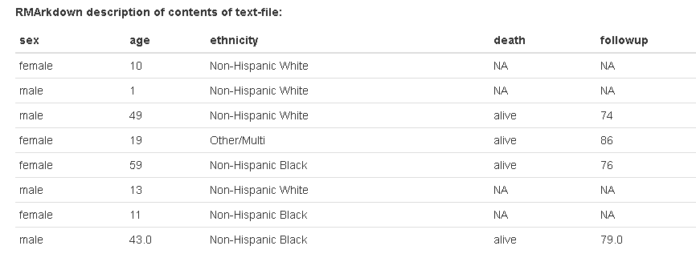

##### Solution

```r
# Question 1 Answers Here:
# create
read.table("assignment1.3.txt", header = TRUE, sep = ",")
```

```
##      sex age         ethnicity death followup
## 1 female  10 Non-HispanicWhite  <NA>       NA
## 2   male   1 Non-HispanicWhite  <NA>       NA
## 3   male  49 Non-HispanicWhite alive       74
## 4 female  19       Other/Multi alive       86
## 5 female  59 Non-HispanicBlack alive       76
## 6   male  13 Non-HispanicWhite  <NA>       NA
## 7 female  11 Non-HispanicBlack  <NA>       NA
## 8   male  43 Non-HispanicBlack alive       79
```

2. **Import the data** into a data.frame named `interesting.sub.table`. In your answer be sure to show the commands and their results. Your data.frame should have the following values:

```r
interesting.sub.table
```

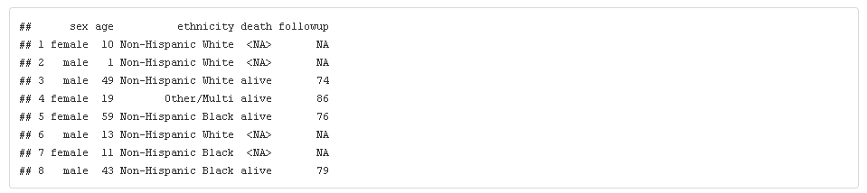

and report the following structure:

```r
str(interesting.sub.table)
```

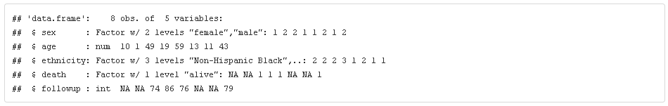

This should be part of your answer. Your answer should also show the contents of the table (just as I did above).

You might notice that the `str` command leaves out a few important details (like the coding for several of the levels for some of the categorical variables). That’s okay– you only need your data.frame to match what you can see from the output above. You will face several subtle but challenging difficulties (int is not the same as num for example). Review the named arguments for `read.table()` carefully. Pay very close attention to the structure of your data– spaces can be problematic and you will need to figure out how to deal with them.

The final command in your answer should display the contents of your textfile in the R-Markdown file. Use `system("cat table.txt",inter=TRUE)`, but replace `table.txt` with the name of your file. It should be in the same subdirectory as the RMarkdown file. (**NOTE:** if you are using RStudio on **your** personal computer, **and** if that computer has windows **and** if you have not installed some set of unix tools on your computer that have the `cat` command… **then** see me for an alternative. (I’m not including it in this assignment because if you are not careful with your commands you might leave file handles hanging which can, eventually, crash your computer. If you’re on the cloud-version of RStudio, then you’d crash the VM for everybody… and we don’t want that.)